# Building an Understanding of How Nodes in Neural Networks Work

## Gary Lawson - 19 May 2019

### 1.0 Abstract

This project focuses on using Python and Keras to build and compare a series of dense, convolutional, and recurrent neural network models of varying configurations to accomplish the natural language processing (NLP) tasks of predicting Reuters article news categories. Several experimental designs were conducted to evaluate model structures and hyperparameters to provide insight into what factors impact model accuracy. Through these experiments, all three network structures were found to be able to predict news categories with accuracies greater than 0.930. One dimensional convolutional neural network proved to be the most accurate with comparatively minimal training times while recurrent neural networks were found to be extremely resource intensive to achieve equal validation accuracies to other models.

### 2.0 Introduction

The intent of this exercise is to begin to experiment with recurrent neural networks (RNNs) and compare the results to dense and convolutional neural networks (CNNs) for time series data. Using a reduced Reuters corpus of news articles and their respective news categories, this project will aim to achieve the following goals: 1) Explore dense versus RNN model structures and results. 2) Explore one-dimensional CNNs versus RNN model structures and results. 3) Explore long short-term memory (LSTM) model architectures. 4) Achieve a firm understanding of how neural networks can accomplish NLP tasks.

### 3.0 Literature Review

For coding examples, a thorough understanding of how RNNs work, and tips on how to tune hyperparameters within a RNN, Chollet (2018) and associated code examples were extremely helpful. I further strengthened my understanding of RNNs, specifically the LSTM and gated recurrent unit (GRU) after reviewing Buduma’s (2015) blog post and the Skymind article. The tutorial by Brownlee (2017) was terrific in breaking down embeddings and conceptualizing how they are created in for use in neural nets. Géron’s textbook (2017) was also helpful in building knowledge around the architectures of RNNs, LSTMs, and GRUs. Last, jumpstart code provided as part of this assignment, as well as code authored by Dr. Thomas Miller in previous courses was used to import and process the text data into embeddings.

### 4.0 Methods

As an initial step in model design and analysis is exploratory data analysis (EDA). In this step, it is important to review the data to get an understanding of what it consists of, as well as preparing it for use in the neural networks. Methods to accomplish this include looking at the number of observations (rows) and features (columns). The dataset used will be a reduced Reuters corpus created to include only news articles with one associated category. To create this reduced corpus, jumpstart code will be used to import the full Reuters dataset from Keras, reduced to the one-category articles, and saved as a json file for later use. Keras tools will then be used to tokenize the text words into vectors. Both pre-trained and learned word embeddings will be used in this project.

The focus of Experiment #8 is to develop 1-dimensional CNN model to compare to the performance of the RNN models developed previously. Additionally, an experiment will be performed to combine a CNN and RNN model to see if a performance increase or training time decrease is experienced.

```python
RANDOM_SEED = 42

EVOCABSIZE_10k = 10000  # specify desired size of pre-defined embedding vocabulary
EVOCABSIZE_20k = 20000
```

```python
# Import packages

###########################################################################################
import sys
import os

# Import base and prepocessing packages
import numpy as np # for creating and working with arrays
import pandas as pd # for creating and working with dataframes
import sklearn as sk
from sklearn.preprocessing import LabelBinarizer # for One Hot Encoding
import time # for recording times on model runs
import pickle  # used for dumping and loading binary files

# To import data
import nltk
from nltk.corpus import reuters
import json # To work with json files
import zipfile # to work with zip folders
from collections import defaultdict

# Import NN packages
import tensorflow as tf
import tensorflow.keras
from keras.models import Sequential
from keras.layers import Embedding, Flatten, Dense, SimpleRNN, LSTM, GRU, Bidirectional, Conv1D, MaxPooling1D, GlobalMaxPooling1D
from keras import backend as K
from keras.utils import plot_model # For visualizing Keras model
from keras.preprocessing.text import Tokenizer # For tokenizing the text
from keras.preprocessing.sequence import pad_sequences
from keras.utils.np_utils import to_categorical # For one-hot encoding


# Import plotting and data visualization packages
import matplotlib.pyplot as plt  # static plotting
import matplotlib as mpl
%matplotlib inline
from collections import OrderedDict  # for creating table output
import IPython # For plotting Keras Model visualizations
import seaborn as sns # For heatmap visualization

# Import seeding packages for reproducible results
from numpy.random import seed
from tensorflow import set_random_seed
import random as rn

###########################################################################################

# Print versions of primary packages
print('Package Versions')
print('***********************************************************************************')
print(f"Tensor Flow Version: {tf.__version__}")
print(f"Keras Version: {tensorflow.keras.__version__}")
print()
print(f"Python {sys.version}")
print(f"Pandas {pd.__version__}")
print(f"Scikit-Learn {sk.__version__}")

# Print specs of this machine
import multiprocessing
import platform
import psutil
from tensorflow.python.client import device_lib

def sizeof_fmt(num, suffix='B'):
    for unit in ['','Ki','Mi','Gi','Ti','Pi','Ei','Zi']:
        if abs(num) < 1024.0:
            return "%3.1f%s%s" % (num, unit, suffix)
        num /= 1024.0
    return "%.1f%s%s" % (num, 'Yi', suffix)

p = platform.processor()
mem = psutil.virtual_memory()

print('\nEnvironment Specifications')
print('***********************************************************************************')
print(f'Your CPU is: {p}')
print(f'Your CPU has {multiprocessing.cpu_count()} cores.')
print(f'Total memory: {sizeof_fmt(mem.total)}')
print(mem)

local_device_protos = device_lib.list_local_devices()
gpuList = [x for x in local_device_protos if x.device_type == 'GPU']

print("Installed GPUs:")
for x in gpuList:
  print("{} - {}".format(x.name,x.physical_device_desc))
```

```
Package Versions
Tensor Flow Version: 1.12.0
Keras Version: 2.1.6-tf

Python 3.6.8 |Anaconda, Inc.| (default, Feb 21 2019, 18:30:04) [MSC v.1916 64 bit (AMD64)]
Pandas 0.24.2
Scikit-Learn 0.20.3

Environment Specifications
Your CPU is: Intel64 Family 6 Model 158 Stepping 9, GenuineIntel
Your CPU has 8 cores.
Total memory: 15.9GiB
svmem(total=17035018240, available=9253335040, percent=45.7, used=7781683200, free=9253335040)
Installed GPUs:
/device:GPU:0 - device: 0, name: GeForce GTX 1050, pci bus id: 0000:01:00.0, compute capability: 6.1
```

```python
# Download the full Reuters dataset
nltk.download('reuters')
```

```
True
```

```python
# Set cutoff for the minimum number of documents per category
# This affects the size of the resulting reuters corpora
# MINDOCS = 40  # gives 15 valid category names
# MINDOCS = 71  # gives 10 valid category names
MINDOCS = 100  # gives 8 valid category names, 5583 train, 2208 test documents
```

##### Collect Data and Reduce Size for Experiment

```python
# Some sample functions for the Reuters corpus are shown in
# https://www.programcreek.com/python/example/104628/nltk.corpus.reuters.fileids
# For example, here is a function for identifying the categories of documents:
def categories(fileids):
    """
    Returns all categories for fileids
    """
    return reuters.categories(fileids)
```

```python
# Check the number of categories in the full corpus
print('Number of categories: ', len(reuters.categories()), '\n')

# Print the names of the categories in the full corpus
print('Category names: ')
print(reuters.categories())


# Print how many files in the full corpus
documents = reuters.fileids()
print(str(len(documents)) + " documents")

# Print how many training docs in the full corpus
initial_train_docs = list(filter(lambda doc: doc.startswith("train"), documents))
print('\n', str(len(initial_train_docs)) + " initial training documents")

# Print file names of first five training docs in the full corpus
print('File names of the first five train documents', initial_train_docs[:5])

# Print how many test docs in the full corpus
initial_test_docs = list(filter(lambda doc: doc.startswith("test"), documents))
print('\n', str(len(initial_test_docs)) + " initial test documents")

# Print file names of first five test docs in the full corpus
print('File names of the first five test documents', initial_test_docs[:5])
```

```
Number of categories:  90

Category names:
['acq', 'alum', 'barley', 'bop', 'carcass', 'castor-oil', 'cocoa', 'coconut', 'coconut-oil', 'coffee', 'copper', 'copra-cake', 'corn', 'cotton', 'cotton-oil', 'cpi', 'cpu', 'crude', 'dfl', 'dlr', 'dmk', 'earn', 'fuel', 'gas', 'gnp', 'gold', 'grain', 'groundnut', 'groundnut-oil', 'heat', 'hog', 'hous…
10788 documents

 7769 initial training documents
File names of the first five train documents ['training/1', 'training/10', 'training/100', 'training/1000', 'training/10000']

 3019 initial test documents
File names of the first five test documents ['test/14826', 'test/14828', 'test/14829', 'test/14832', 'test/14833']
```

```python
print('File names of the first five train documents', initial_train_docs[:5])
```

```
File names of the first five train documents ['training/1', 'training/10', 'training/100', 'training/1000', 'training/10000']
```

```python
# Review of the original Reuters data shows that some documents
# are associated with more than one category. This complicates
# the text classification task. So let's retain only those
# documents associated with one and only one category.
train_docs = []
test_docs = []
```

```python
for train_name in initial_train_docs:
    if len(categories(train_name)) == 1:
        train_docs.append(train_name)
print('\n', str(len(train_docs)) + " train documents associated with one category only")
```

```
 6577 train documents associated with one category only
```

```python
for test_name in initial_test_docs:
    if len(categories(test_name)) == 1:
        test_docs.append(test_name)
print('\n', str(len(test_docs)) + " test documents associated with one category only")
```

```
 2583 test documents associated with one category only
```

```python
# Define lists of categories associated with the final train_docs and test_docs
train_categorys = []
test_categorys = []
```

```python
for train_name in train_docs:
    train_categorys.append(categories(train_name))

# Determine the number of documents associated with each category
vals, counts = np.unique(train_categorys, return_counts=True)
train_df = pd.DataFrame({'vals':vals,'counts':counts})
print('\nTrain documents per category:')
print(train_df)
```

```
Train documents per category:
               vals  counts
0               acq    1596
1              alum      31
2               bop      22
3           carcass       6
4             cocoa      46
5            coffee      90
6            copper      31
7            cotton      15
8               cpi      54
9               cpu       3
10            crude     253
11              dlr       3
12              dmk       1
```

[output cut: 45 more lines]

```python
for test_name in test_docs:
    test_categorys.append(categories(test_name))

vals, counts = np.unique(test_categorys, return_counts=True)
test_df = pd.DataFrame({'vals':vals,'counts':counts})
print('\nTest documents per category:')
print(test_df)
```

```
Test documents per category:
               vals  counts
0               acq     696
1              alum      19
2               bop       9
3           carcass       5
4             cocoa      15
5           coconut       1
6            coffee      22
7            copper      13
8            cotton       9
9               cpi      17
10              cpu       1
11            crude     121
12              dlr       3
```

[output cut: 46 more lines]

```python
# Identify the categories that have at least MINDOCS train documents
print('\nTrain documents per valid category')
valid_train = train_df[train_df['counts'] >= MINDOCS]

# valid_train = train_df.query("counts > 50")
print(valid_train)
print('\n', valid_train['counts'].sum(), 'valid train documents')

valid_categories = list(valid_train['vals'])
print('\nList of', len(valid_categories),
    'valid category names:\n', valid_categories)

valid_test = test_df[test_df['vals'].isin(valid_categories)]
print('\nCorresponding test documents per valid category')
print(valid_test)
print('\n', valid_test['counts'].sum(), 'valid test documents')
```

```
Train documents per valid category
            vals  counts
0            acq    1596
10         crude     253
13          earn    2840
23      interest     191
34      money-fx     222
35  money-supply     123
48          ship     108
54         trade     250

 5583 valid train documents

List of 8 valid category names:
 ['acq', 'crude', 'earn', 'interest', 'money-fx', 'money-supply', 'ship', 'trade']

Corresponding test documents per valid category
            vals  counts
0            acq     696
11         crude     121
13          earn    1083
25      interest      81
35      money-fx      87
36  money-supply      28
49          ship      36
54         trade      76

 2208 valid test documents
```

```python
# Create reuters_train and reuters_test corpora
# containing documents within the list of valid categories
reuters_train_file_name = []
reuters_train_category = []
reuters_train_text = []
for train_name in train_docs:
    if set(categories(train_name)).issubset(set(valid_categories)):
        reuters_train_file_name.append(train_name)
        reuters_train_category.append(categories(train_name))
        reuters_train_text.append(reuters.raw(train_name))

print('\n', str(len(reuters_train_file_name)) + " train documents count check")
print('\n', str(len(reuters_train_category)) + " train labels count check")
print('\n', str(len(reuters_train_text)) + " train text count check")

# create dictionary for reuters_train corpus for possible later use
reuters_train_dict = {'corpus':['reuters']*len(reuters_train_file_name),
                      'dataset':['train']*len(reuters_train_file_name),
                      'filename':reuters_train_file_name,
                      'category':reuters_train_category,
                      'text':reuters_train_text}
reuters_train_df = pd.DataFrame(reuters_train_dict)  # for possible later use
```

```
 5583 train documents count check

 5583 train labels count check

 5583 train text count check
```

```python
reuters_test_file_name = []
reuters_test_category = []
reuters_test_text = []
for test_name in test_docs:
    if set(categories(test_name)).issubset(set(valid_categories)):
        reuters_test_file_name.append(test_name)
        reuters_test_category.append(categories(test_name))
        reuters_test_text.append(reuters.raw(test_name))

print('\n', str(len(reuters_test_file_name)) + " test documents count check")
print('\n', str(len(reuters_test_category)) + " test labels count check")
print('\n', str(len(reuters_test_text)) + " test text count check")

# create dictionary for reuters_test corpus for possible later use
reuters_test_dict = {'corpus':['reuters']*len(reuters_test_file_name),
                     'dataset':['test']*len(reuters_test_file_name),
                     'filename':reuters_test_file_name,
                     'category':reuters_test_category,
                     'text':reuters_test_text}
reuters_test_df = pd.DataFrame(reuters_test_dict)  # for possible later use
```

```
 2208 test documents count check

 2208 test labels count check

 2208 test text count check
```

```python
# export reuters_train corpus as JSON lines file
with open('reuters_train.jl', 'wt') as f:
    for item in range(len(reuters_train_file_name)):
        itemdict = {'corpus':'reuters',
                    'dataset':'train',
                    'filename':reuters_train_file_name[item],
                    'category':reuters_train_category[item][0],
                    'text':reuters_train_text[item]}
        f.write(json.dumps(itemdict))
        if item < len(reuters_train_file_name)-1:
            f.write('\n')
print('\nReuters train data written to JSON lines file reuters_train.jl')
```

```
Reuters train data written to JSON lines file reuters_train.jl
```

```python
# export reuters_test corpus as JSON lines file
with open('reuters_test.jl', 'wt') as f:
    for item in range(len(reuters_test_file_name)):
        itemdict = {'corpus':'reuters',
                    'dataset':'test',
                    'filename':reuters_test_file_name[item],
                    'category':reuters_test_category[item][0],
                    'text':reuters_test_text[item]}
        f.write(json.dumps(itemdict))
        if item < len(reuters_test_file_name)-1:
            f.write('\n')
print('\nReuters test data written to JSON lines file reuters_test.jl')
```

```
Reuters test data written to JSON lines file reuters_test.jl
```

##### Extract Data from JSON Files for Use in Experiment

```python
# Define a function to look at files available in zip folder
#import zipfile

def zip_file_names(zip_loc):
    with zipfile.ZipFile(zip_loc, "r") as z:
       for filename in z.namelist():
          print(filename)

#https://stackoverflow.com/questions/40824807/reading-zipped-json-files
```

```python
# Set the file locations for data and other resources
data_zip_loc = "C:/Users/DELL/Documents/Data Warehouse/reuters-corpus-v001.zip"
glove_zip_loc = "C:/Users/DELL/Documents/Data Warehouse/embeddings/gloVe.6B.zip"
```

```python
zip_file_names(data_zip_loc)
```

```
reuters-corpus-v001/README
reuters-corpus-v001/reuters_test.jl
reuters-corpus-v001/reuters_train.jl
reuters-corpus-v001/run-reuters-v001.py
```

```python
# Define function to open up a json file in a zip folder
#import json
#import zipfile

def zip_open_file(zip_loc, file_name, var_name):
    with zipfile.ZipFile(zip_loc, "r") as z:
        for line in open(file_name, 'r'):
            var_name.append(json.loads(line))

#https://stackoverflow.com/questions/40824807/reading-zipped-json-files
```

```python
# Load the data from a json into a list
train_import = []
zip_open_file(data_zip_loc, 'reuters_train.jl',train_import)

# Convert list into DataFrame
train_import_df = pd.DataFrame.from_records(train_import)
train_import_df
```

|  | category | corpus | dataset | filename | text |
| --- | --- | --- | --- | --- | --- |
| 0 | acq | reuters | train | training/10 | COMPUTER TERMINAL SYSTEMS &lt;CPML> COMPLETES ... |
| 1 | money-supply | reuters | train | training/100 | N.Z. TRADING BANK DEPOSIT GROWTH RISES SLIGHTL... |
| 2 | acq | reuters | train | training/1000 | NATIONAL AMUSEMENTS AGAIN UPS VIACOM &lt;VIA> ... |
| 3 | earn | reuters | train | training/10000 | ROGERS &lt;ROG> SEES 1ST QTR NET UP SIGNIFICAN... |
| 4 | earn | reuters | train | training/10002 | ISLAND TELEPHONE SHARE SPLIT APPROVED\n &lt;I... |
| 5 | earn | reuters | train | training/10008 | QUESTECH INC &lt;QTEC> YEAR NET\n Shr loss ni... |
| 6 | acq | reuters | train | training/10018 | GOULD&lt;GLD> COMPLETES SALE OF FRENCH BATTERY... |
| 7 | earn | reuters | train | training/10023 | SHOE TOWN INC &lt;SHU> YEAR ENDED JAN THREE 19... |
| 8 | acq | reuters | train | training/10025 | FIRST WISCONSIN &lt;FWB> TO BUY MINNESOTA BANK... |
| 9 | earn | reuters | train | training/10027 | AMERICAN NURSERY PRODUCTS &lt;ANSY> 3RD QTR NE... |
| 10 | earn | reuters | train | training/1003 | NATIONAL FSI INC &lt;NFSI> 4TH QTR LOSS\n Shr... |
| 11 | earn | reuters | train | training/10032 | DISCUS CORP &lt;DISC> 4TH QTR LOSS\n Shr loss... |
| 12 | earn | reuters | train | training/10035 | ENTERTAINMENT PUBLICATIONS SEES 31 CTS/SHR 3RD... |
| 13 | earn | reuters | train | training/10037 | PAY 'N PAK STORES INC &lt;PNP> 4TH QTR FEB 28 ... |
| 14 | earn | reuters | train | training/10040 | AMERICAN NURSERY PRODUCTS &lt;ANSY> 3RD QTR NE... |
| 15 | earn | reuters | train | training/10041 | VOLVO 1986 RESULT OFF SLIGHTLY FROM 1985\n AB... |
| 16 | acq | reuters | train | training/10042 | &lt;MERIDIAN ENERGY>, CASTONE END LETTER OF IN... |
| 17 | earn | reuters | train | training/10046 | GOLDFIELD CORP &lt;GV> 4TH QTR NET LOSS\n Shr... |
| 18 | money-fx | reuters | train | training/10048 | BRITISH, FRENCH MINISTERS DISCUSS PUBLIC SPEND... |
| 19 | acq | reuters | train | training/10049 | FED'S HELLER URGES BROAD REFORM TO AID BANKING... |
| 20 | earn | reuters | train | training/10050 | FEDERATED DEPARTMENT STORES INC UPS QTLY DIV B... |
| 21 | acq | reuters | train | training/10052 | GOULD &lt;GLD> SELLS FRENCH BATTERY UNIT\n Go... |
| 22 | earn | reuters | train | training/10053 | ADVANCED GENETIC SCIENCES &lt;AGSI> YEAR LOSS\... |
| 23 | earn | reuters | train | training/10054 | FEDERATED DEPARTMENT &lt;FDS> RAISES QTLY DIVI... |
| 24 | earn | reuters | train | training/10057 | DANZAR INVESTMENT &lt;DNZR> SETS SPECIAL DIVID... |
| 25 | acq | reuters | train | training/10058 | FIDELITY &lt;FNF> UNIT ACQUIRES CALIFORNIA CON... |
| 26 | earn | reuters | train | training/10061 | HOME SAVINGS BANK &lt;HMSB> SETS INITIAL DIVID... |
| 27 | earn | reuters | train | training/10064 | AMERICAN BRANDS SEES RECORD FIRST QUARTER RESU... |
| 28 | acq | reuters | train | training/10065 | BP MANAGING DIRECTOR SAYS COMPANY DOES NOT PLA... |
| 29 | acq | reuters | train | training/10066 | SECURITY &lt;SPC>, USERS, END MERGER TALKS\n ... |
| ... | ... | ... | ... | ... | ... |
| 5553 | acq | reuters | train | training/9942 | USAIR GETS APPROVAL TO BUY 9,309,394 PIEDMONT ... |
| 5554 | interest | reuters | train | training/9943 | FED EXPECTED TO ADD RESERVES\n The Federal Re... |
| 5555 | earn | reuters | train | training/995 | FIRSTCORP &lt;FCR> SEES GAIN ON CONDEMNATION\n... |
| 5556 | earn | reuters | train | training/9952 | NORCEN SEES IMPROVEMENT IN 1987 EARNINGS\n &l... |
| 5557 | acq | reuters | train | training/9954 | SIEMENS REBUTTS U.S. CRITICISM ON CGCT OFFER\n... |
| 5558 | money-fx | reuters | train | training/9955 | MULFORD DISAPPOINTED IN NEWLY INDUSTRIALIZED (... |
| 5559 | earn | reuters | train | training/9956 | FORD &lt;F> NEARS GM &lt;GM> IN EXECUTIVE BONU... |
| 5560 | earn | reuters | train | training/9959 | PIER 1 IMPORTS &lt;PIR> DECLARES STOCK SPLIT\n... |
| 5561 | earn | reuters | train | training/9961 | LANCER CORP &lt;LACR> 4TH QTR NET\n Shr 12 ct... |
| 5562 | earn | reuters | train | training/9963 | MACNEAL-SCHWENDLER CORP &lt;MNS> 4TH QTR JAN 3... |
| 5563 | earn | reuters | train | training/9964 | NICHOLS INSTITUTE &lt;LAB> 1ST QTR FEB 28 NET\... |
| 5564 | earn | reuters | train | training/9965 | FIRST MEDICAL DEVICES CORP &lt;FMDC> YEAR LOSS... |
| 5565 | earn | reuters | train | training/9967 | HEALTHMATE &lt;HMTE> EXPECTS QUALIFIED OPINION... |
| 5566 | earn | reuters | train | training/9970 | HEALTHMATE INC &lt;HMTE> 4TH QTR LOSS\n Shr l... |
| 5567 | acq | reuters | train | training/9971 | USAIR &lt;U> CLEARED TO BUY PIEDMONT &lt;PIE> ... |
| 5568 | interest | reuters | train | training/9972 | FED SETS TWO BILLION DLR CUSTOMER REPURCHASE, ... |
| 5569 | earn | reuters | train | training/9973 | HOUSE OF FABRICS INC &lt;HF> 4TH QTR JAN 31 NE... |
| 5570 | money-fx | reuters | train | training/9975 | GERMAN WAGE ROUND SAID TO LIMIT MONETARY OPTIO... |
| 5571 | acq | reuters | train | training/9976 | FOREIGN FIRMS HOPE TO JOIN JAPAN TELECOM COMPA... |
| 5572 | acq | reuters | train | training/9977 | SIEMENS RAISES STAKE IN TELECOM PLUS OF U.S.\n... |
| 5573 | acq | reuters | train | training/9978 | FIRST INTERSTATE SEEKS ACQUISITION\n Less tha... |
| 5574 | earn | reuters | train | training/998 | &lt;NATIONAL SEA PRODUCTS LTD> 4TH QTR NET\n ... |
| 5575 | earn | reuters | train | training/9981 | HOUSE OF FABRICS &lt;HF> SEES RESULTS IMPROVIN... |
| 5576 | acq | reuters | train | training/9984 | KODAK &lt;EK> BUYS STAKE IN BIOTECHNOLOGY COMP... |
| 5577 | earn | reuters | train | training/9985 | AVERY &lt;AVY> 1ST QTR FEB 28 NET\n Shr 33 ct... |
| 5578 | interest | reuters | train | training/9988 | FED SETS TWO BILLION DLR CUSTOMER REPURCHASE\n... |
| 5579 | earn | reuters | train | training/9992 | KNIGHT-RIDDER INC &lt;KRN> SETS QUARTERLY\n Q... |
| 5580 | earn | reuters | train | training/9993 | TECHNITROL INC &lt;TNL> SETS QUARTERLY\n Qtly... |
| 5581 | earn | reuters | train | training/9994 | NATIONWIDE CELLULAR SERVICE INC &lt;NCEL> 4TH ... |
| 5582 | earn | reuters | train | training/9995 | &lt;A.H.A. AUTOMOTIVE TECHNOLOGIES CORP> YEAR ... |

5583 rows × 5 columns

```python
# Load the data from a json into a list
test_import = []
zip_open_file(data_zip_loc, 'reuters_test.jl',test_import)

# Convert list into DataFrame
test_import_df = pd.DataFrame.from_records(test_import)
test_import_df
```

|  | category | corpus | dataset | filename | text |
| --- | --- | --- | --- | --- | --- |
| 0 | trade | reuters | test | test/14826 | ASIAN EXPORTERS FEAR DAMAGE FROM U.S.-JAPAN RI... |
| 1 | ship | reuters | test | test/14839 | AUSTRALIAN FOREIGN SHIP BAN ENDS BUT NSW PORTS... |
| 2 | acq | reuters | test | test/14843 | SUMITOMO BANK AIMS AT QUICK RECOVERY FROM MERG... |
| 3 | earn | reuters | test | test/14859 | AMATIL PROPOSES TWO-FOR-FIVE BONUS SHARE ISSUE... |
| 4 | earn | reuters | test | test/14860 | BOWATER 1986 PRETAX PROFITS RISE 15.6 MLN STG\... |
| 5 | acq | reuters | test | test/14865 | CRA SOLD FORREST GOLD FOR 76 MLN DLRS - WHIM C... |
| 6 | earn | reuters | test | test/14872 | BOWATER INDUSTRIES PROFIT EXCEED EXPECTATIONS\... |
| 7 | earn | reuters | test | test/14873 | CITIBANK NORWAY UNIT LOSES SIX MLN CROWNS IN 1... |
| 8 | earn | reuters | test | test/14875 | VIEILLE MONTAGNE SAYS 1986 CONDITIONS UNFAVOUR... |
| 9 | earn | reuters | test | test/14876 | VIEILLE MONTAGNE REPORTS LOSS, DIVIDEND NIL\n ... |
| 10 | trade | reuters | test | test/14881 | JAPAN GIVEN LITTLE HOPE OF AVOIDING U.S. SANCT... |
| 11 | acq | reuters | test | test/14888 | ANHEUSER-BUSCH JOINS BID FOR SAN MIGUEL\n Anh... |
| 12 | earn | reuters | test | test/14899 | JARDINE MATHESON SAID IT SETS TWO-FOR-FIVE BON... |
| 13 | acq | reuters | test | test/14900 | MONIER SAYS BRITAIN'S REDLAND MAY BID FOR IT\n... |
| 14 | earn | reuters | test | test/14903 | ISUZU PLANS NO INTERIM DIVIDEND\n Isuzu Motor... |
| 15 | trade | reuters | test | test/14904 | JAPANESE OFFICIAL TAKES DATA TO MICROCHIP TALK... |
| 16 | acq | reuters | test | test/14907 | BELL GROUP CONFIRMS STANDARD CHARTERED STAKE\n... |
| 17 | acq | reuters | test | test/14909 | NIPPON STEEL DENIES CHINA SEEKING JAPANESE PLA... |
| 18 | earn | reuters | test | test/14911 | JARDINE MATHESON REPLACES "B" SHARE BY BONUS I... |
| 19 | trade | reuters | test | test/14912 | JAPAN GIVEN LITTLE HOPE OF AVOIDING U.S. SANCT... |
| 20 | acq | reuters | test | test/14921 | SAN MIGUEL DEAL HIT BY MORE LAWSUITS\n A bid ... |
| 21 | earn | reuters | test | test/14926 | ITALY'S LA FONDIARIA TO REPORT HIGHER 1986 PRO... |
| 22 | earn | reuters | test | test/14930 | HIGHER 1986 PROFIT FOR DUTCH CHEMICAL FIRM DSM... |
| 23 | acq | reuters | test | test/14932 | CINCINNATI BELL &lt;CSN> STARTS AUXTON &lt;AUX... |
| 24 | earn | reuters | test | test/14933 | CALIFORNIA BIOTECH &lt;CBIO> SEES 1ST QTR LOSS... |
| 25 | earn | reuters | test | test/14934 | PALL CORP &lt;PLL> SETS QUARTERLY DIVIDEND\n ... |
| 26 | acq | reuters | test | test/14941 | UNILEVER SEEKS BUYER FOR STAUFFER CHEMICAL\n ... |
| 27 | acq | reuters | test | test/14943 | CONRAC CORP SAID IT HAS ENTERED TALKS ON ITS A... |
| 28 | acq | reuters | test | test/14949 | CONRAC &lt;CAX> IN MERGER TALKS WITH SEVERAL\n... |
| 29 | earn | reuters | test | test/14954 | COMPUTER RESEARCH INC &lt;CORE> 2ND QTR FEB 28... |
| ... | ... | ... | ... | ... | ... |
| 2178 | acq | reuters | test | test/21466 | CABLE AND WIRELESS RESTRUCTURES H.K. UNITS\n ... |
| 2179 | acq | reuters | test | test/21469 | GAF &lt;GAF> GROUP RECONSIDERS BUYOUT BID\n G... |
| 2180 | earn | reuters | test | test/21474 | PLY GEM INDUSTRIES INC &lt;PGI> 3RD QTR NET\n ... |
| 2181 | money-fx | reuters | test | test/21477 | DEUTSCHE BANK CHIEF SAYS LOUVRE PACT STILL INT... |
| 2182 | acq | reuters | test | test/21478 | GAF CORP SAID MANAGEMENT GROUP TO RECONSIDER A... |
| 2183 | earn | reuters | test | test/21479 | EMULEX CORP &lt;EMLX.O> 1ST QTR SEPT 27 NET\n ... |
| 2184 | earn | reuters | test | test/21480 | LYPHOMED INC &lt;LMED.O> 3RD QTR NET\n Shr 18... |
| 2185 | crude | reuters | test | test/21484 | SHIPPING SOURCES SAY UNIDENTIFIED JETS RAID IR... |
| 2186 | earn | reuters | test | test/21488 | INTELLICORP &lt;INAI.O> 1ST QTR SEPT 30 LOSS\n... |
| 2187 | earn | reuters | test | test/21489 | OWENS AND MINOR INC &lt;OBOD.O> 3RD QTR NET\n ... |
| 2188 | earn | reuters | test | test/21490 | TRINOVA CORP &lt;TNV> 3RD QTR NET\n Shr 52 ct... |
| 2189 | ship | reuters | test | test/21501 | PENTAGON HAS NO INFORMATION ON IRAN ATTACK RUM... |
| 2190 | crude | reuters | test | test/21502 | SOUTH YEMEN PLANS OIL EXPORT PIPELINE - MEES\n... |
| 2191 | acq | reuters | test | test/21503 | TRAFALGAR HOUSE BUYS U.S. BUILDER FOR 20 MLN D... |
| 2192 | money-fx | reuters | test | test/21512 | BALLADUR INSISTS ON MAINTENANCE OF LOUVRE ACCO... |
| 2193 | ship | reuters | test | test/21517 | IRAN WARNS U.S. AGAINST RAISING TENSION IN GUL... |
| 2194 | money-fx | reuters | test | test/21521 | BONN MINISTRY HAS NO COMMENT ON BAKER REMARKS\... |
| 2195 | ship | reuters | test | test/21523 | ANIMAL FEED SHIP ON FIRE AGAIN AT CHINESE PORT... |
| 2196 | acq | reuters | test | test/21538 | EQUITICORP HOLDING IN GUINNESS REACHES 59.93 P... |
| 2197 | money-fx | reuters | test | test/21539 | BANKS EXTEND TRADING HALT IN LEBANESE POUND\n ... |
| 2198 | crude | reuters | test | test/21541 | STATOIL PLACES NORTH SEA VESLEFRIKK FIELD ORDE... |
| 2199 | acq | reuters | test | test/21550 | CABLE AND WIRELESS DETAILS MERGER OF H.K. UNIT... |
| 2200 | earn | reuters | test | test/21551 | TDK GROUP NET UP 17.6 PCT IN NINE MONTHS\n Ni... |
| 2201 | earn | reuters | test | test/21553 | TDK GROUP NET UP 0.5 PCT IN THREE MONTHS TO AU... |
| 2202 | acq | reuters | test | test/21555 | CABLE AND WIRELESS TO MERGE TWO H.K. UNITS INT... |
| 2203 | money-fx | reuters | test | test/21556 | BALLADUR INSISTS ON MAINTENANCE OF LOUVRE ACCO... |
| 2204 | trade | reuters | test | test/21562 | PHILIPPINE TRADE GAP WIDENS IN JANUARY-AUGUST\... |
| 2205 | crude | reuters | test | test/21568 | IRAN, SOVIET UNION TO SWAP CRUDE, REFINED PROD... |
| 2206 | acq | reuters | test | test/21571 | N.Z.'S CHASE CORP MAKES OFFER FOR ENTREGROWTH\... |
| 2207 | ship | reuters | test | test/21574 | JAPAN/INDIA CONFERENCE CUTS GULF WAR RISK CHAR... |

2208 rows × 5 columns

```python
print(train_import_df.category.unique())
print(test_import_df.category.unique())
```

```
['acq' 'money-supply' 'earn' 'money-fx' 'crude' 'interest' 'trade' 'ship']
['trade' 'ship' 'acq' 'earn' 'money-fx' 'interest' 'crude' 'money-supply']
```

```python
# In order to one-hot encode text labels, need to prepare labels into one word so when tokenized, not seen as 2 labels.
train_import_df['category'] = np.where(train_import_df['category']=='money-supply',
                                       'moneySupply',
                                       train_import_df['category'])

train_import_df['category'] = np.where(train_import_df['category']=='money-fx',
                                       'moneyFx',
                                       train_import_df['category'])

test_import_df['category'] = np.where(test_import_df['category']=='money-supply',
                                       'moneySupply',
                                       test_import_df['category'])

test_import_df['category'] = np.where(test_import_df['category']=='money-fx',
                                       'moneyFx',
                                       test_import_df['category'])
```

```python
# Tokenize the words for use in an RNN

#from keras.preprocessing.text import Tokenizer
#from keras.preprocessing.sequence import pad_sequences
#from keras.utils.np_utils import to_categorical

max_words = 10000 # Considers only the top 10,000 words in the dataset
maxlen = 900

X_tokenizer = Tokenizer(num_words=max_words) # Instantiat
X_tokenizer.fit_on_texts(train_import_df['text'])

y_tokenizer = Tokenizer(num_words=max_words) # Instantiat
y_tokenizer.fit_on_texts(train_import_df['category'])

# Apply tokenizer to training data
train_sequences = X_tokenizer.texts_to_sequences(train_import_df['text'])
word_index = X_tokenizer.word_index
print('Found %s unique tokens.' %len(word_index))
train_data = pad_sequences(train_sequences, maxlen=maxlen)

train_label_sequences = y_tokenizer.texts_to_sequences(train_import_df['category'])
train_labels = np.asarray(train_label_sequences)
train_labels = to_categorical(train_labels)
print('Shape of train data tensor:', train_data.shape)
print('Shape of train label tensor:', train_labels.shape)

# Apply tokenizer to test data
test_sequences = X_tokenizer.texts_to_sequences(test_import_df['text'])
test_data = pad_sequences(test_sequences, maxlen=maxlen)

test_label_sequences = y_tokenizer.texts_to_sequences(test_import_df['category'])
test_labels = np.asarray(test_label_sequences)
test_labels = to_categorical(test_labels)
print('Shape of test data tensor:', test_data.shape)
print('Shape of test label tensor:', test_labels.shape)
```

```
Found 22358 unique tokens.
Shape of train data tensor: (5583, 900)
Shape of train label tensor: (5583, 9)
Shape of test data tensor: (2208, 900)
Shape of test label tensor: (2208, 9)
```

```python
'''
# Load in json file as a list
train_import = []
for line in open('reuters_train.jl', 'r'):
    train_import.append(json.loads(line))

# Convert list into DataFrame
train_import_df = pd.DataFrame.from_records(train_import)
train_import_df
'''
```

```
"\n# Load in json file as a list\ntrain_import = []\nfor line in open('reuters_train.jl', 'r'):\n    train_import.append(json.loads(line))\n\n# Convert list into DataFrame\ntrain_import_df = pd.DataFrame.from_records(train_import)\ntrain_import_df\n"
```

```python
'''
# Load in json file as a list
test_import = []
for line in open('reuters_test.jl', 'r'):
    test_import.append(json.loads(line))

# Convert list into DataFrame
test_import_df = pd.DataFrame.from_records(test_import)
test_import_df
'''
```

```
"\n# Load in json file as a list\ntest_import = []\nfor line in open('reuters_test.jl', 'r'):\n    test_import.append(json.loads(line))\n\n# Convert list into DataFrame\ntest_import_df = pd.DataFrame.from_records(test_import)\ntest_import_df\n"
```

##### Import Word Embeddings

```python
# -------------------------------------------------------------
# Select the pre-defined embeddings source
# Define vocabulary size for the language model
# Create a word_to_embedding_dict for GloVe.6B.50d
embeddings_directory = 'C:/Users/DELL/Documents/Data Warehouse/embeddings/gloVe.6B'
filename = 'glove.6B.50d.txt'
embeddings_filename_50d = os.path.join(embeddings_directory, filename)

# I will also select the 300 dimension embedding to test
filename_300d = 'glove.6B.300d.txt'
embeddings_filename_300d = os.path.join(embeddings_directory, filename_300d)
# -------------------------------------------------------------
```

```python
embeddings_index = {}
def parse_word_embed(filename, var_name):
    f = open(embeddings_filename_50d, encoding="utf8")
    for line in f:
        values = line.split()
        word = values[0]
        coefs = np.asarray(values[1:], dtype='float32')
        embeddings_index[word] = coefs
    f.close()

    print('Found %s word vectors.' %len(embeddings_index))
```

```python
embeddings_index_50d = {}
parse_word_embed(embeddings_filename_50d, embeddings_index_50d)
```

```
Found 400000 word vectors.
```

```python
embeddings_index_300d = {}
parse_word_embed(embeddings_filename_300d, embeddings_index_300d)
```

```
Found 400000 word vectors.
```

#### Functions For Use in Modelling

```python
# I actually could not get this to work properly, as it seemed to have some sort of memory.  When I switched up the
# "create_model" passed to this function, I would still get the same results as the previous run.  I am leaving the code
# here so I can experiment futher at a later date.

# Define a function to loop through model iterations and tabulate information
def model_loop(create_model, model_id, model_type, mod_layers, mod_nodes, hidden_activation, optimizer, exp_no):
    for nodes in mod_nodes:
        for hid_act in hidden_activation:

            # Print the basic parameters of the model being iterated
            print('---------------------------------------------------------------')
            print("Model No.: %r" %model_id)
            print("Model Type: %r" %model_type)
            print("Number of Layers: %r" %mod_layers)
            print("Number of Nodes: %r" %nodes)
            print("Hidden Layer Activiation: %r" %hid_act)
            print("Hidden Layer Optimizer: %r" %optimizer)

            start_time = time.clock() # start timer to evaluate how long it takes to train this base model

            # Set seeds for reproducible results
            seed(1)
            set_random_seed(2)
            rn.seed(3)

            # Call the model that is specified outside of this loop.  This allows for the structure of the model
            # to be defined prior to being called in this function.
            create_model

            # Fit the model to the train data and use the test data as validation
            history = model.fit(train_data, train_labels,
                                    epochs=mod_epochs,
                                    batch_size=mod_batch_size,
                                    validation_data=(test_data, test_labels))

            #model.save_weights('pre_trained_glove_model.h5')

            # Stop the timer and append time to list
            end_time = time.clock() # end timer
            runtime = end_time - start_time  # seconds of wall-clock time
            print("\nProcessing time (seconds): %f" % runtime)  # print process time to train model
            processing_time.append(runtime) # append process time results to list for comparison table

            # Identify and print maximum accuracy and epoch where that accuracy was realized
            epoch_max = np.argmax(history.history['acc'])
            acc_max = max(history.history['acc'])
            print('Maxium Accuarcy: %r, Epochs Required to Achieve this Accuracy: %r' %(acc_max, epoch_max))

            # Print validation accuracy
            val_acc_max = max(history.history['val_acc'])
            print("Validation Accuracy: %r" %val_acc_max)

            # Plot the accuracy and loss of each model iteration
            plot_figs(model_id, model_type, nodes)

            # Append lists with values for this model ID
            model_id_list.append(model_id)
            model_type_list.append(model_type)
            embedding_dim_list.append(embedding_dim)
            article_len_list.append(article_len)
            n_layer_list.append(mod_layers)
            node_list.append(nodes)
            hidden_activation_list.append(hid_act)
            out_activation_list.append(out_activation)
            optimizer_list.append(optimizer)
            max_acc_list.append(acc_max)
            valid_perform_list.append(val_acc_max)
            epoch_max_list.append(epoch_max)
            batch_size_list.append(mod_batch_size)

            model_id += 1
            ### END LOOP
```

```python
# Define a function to plot Model Accuracy and Model Loss

def plot_figs(model_id, model_type, mod_nodes):
    # Create plot figure
    plt.figure(figsize=(15,3))

    # Calculate accuracy and loss variables
    acc = history.history['acc']
    val_acc = history.history['val_acc']
    loss = history.history['loss']
    val_loss = history.history['val_loss']

    epochs = range(1, len(acc)+1)

    # Plot training and validation accuracy
    plt.subplot(1,2,1) # Subplot #1
    plt.plot(epochs, acc, 'bo', label='Training acc')
    plt.plot(epochs, val_acc, 'b', label='Validation acc')
    plt.legend()
    plt.title('Model Accuracy for Model No. %r,\n Model Type %r, \nNo. of Nodes: %r'\
          %(model_id, model_type, mod_nodes))
    plt.ylabel('Accuracy')
    plt.xlabel('Epoch')

    # Plot training and validation loss
    plt.subplot(1,2,2) # Subplot #1
    plt.plot(epochs, loss, 'bo', label='Training loss')
    plt.plot(epochs, val_loss, 'b', label='Validation loss')
    plt.legend()
    plt.title('Model Loss for Model No. %r,\n Model Type %r, \nNo. of Nodes: %r'\
          %(model_id, model_type, mod_nodes))
    plt.ylabel('Accuracy')
    plt.xlabel('Epoch')
```

#### Experiment #1 - Basic Dense Model Without Pretrained Word Embeddings

```python
# Specify attributes about this model
exp_no = 1 # Experiment Number
model_type = 'Dense NN'
embedding_dim = 50
article_len = 900
mod_layers = 1
mod_nodes = [16, 32, 64]
hidden_activation = ['sigmoid','relu','tanh']
out_activation = 'softmax'
optimizer = 'rmsprop'
mod_epochs = 10
mod_batch_size = 32
```

```python
# Create lists to hold the results of each iteration.
model_id = 1 # initial model ID
model_id_list = []
model_type_list = []
embedding_dim_list = []
article_len_list = []
n_layer_list = []
node_list = []
hidden_activation_list = []
out_activation_list = []
optimizer_list = []
max_acc_list = []
valid_perform_list = []
epoch_max_list = []
batch_size_list = []
processing_time = []
```

```
---------------------------------------------------------------
Model No.: 1
Model Type: 'Dense NN'
Number of Layers: 1
Number of Nodes: 16
Hidden Layer Activiation: 'sigmoid'
Hidden Layer Optimizer: 'rmsprop'
Train on 5583 samples, validate on 2208 samples

Processing time (seconds): 18.449520
Maxium Accuarcy: 0.9974923876052302, Epochs Required to Achieve this Accuracy: 8
Validation Accuracy: 0.9424818840579711
---------------------------------------------------------------
Model No.: 2
Model Type: 'Dense NN'
Number of Layers: 1
Number of Nodes: 16
Hidden Layer Activiation: 'relu'
Hidden Layer Optimizer: 'rmsprop'
Train on 5583 samples, validate on 2208 samples

Processing time (seconds): 18.007741
Maxium Accuarcy: 0.9976715027762851, Epochs Required to Achieve this Accuracy: 9
Validation Accuracy: 0.9338768115942029
---------------------------------------------------------------
Model No.: 3
Model Type: 'Dense NN'
Number of Layers: 1
Number of Nodes: 16
Hidden Layer Activiation: 'tanh'
Hidden Layer Optimizer: 'rmsprop'
Train on 5583 samples, validate on 2208 samples

Processing time (seconds): 18.276198
Maxium Accuarcy: 0.9982088482894501, Epochs Required to Achieve this Accuracy: 9
Validation Accuracy: 0.9429347826086957
---------------------------------------------------------------
Model No.: 4
Model Type: 'Dense NN'
Number of Layers: 1
```

[output cut: 53 more lines]

```
Processing time (seconds): 18.435958
Maxium Accuarcy: 0.9976715027762851, Epochs Required to Achieve this Accuracy: 9
Validation Accuracy: 0.9338768115942029
---------------------------------------------------------------
Model No.: 9
Model Type: 'Dense NN'
Number of Layers: 1
Number of Nodes: 64
Hidden Layer Activiation: 'tanh'
Hidden Layer Optimizer: 'rmsprop'
Train on 5583 samples, validate on 2208 samples

Processing time (seconds): 18.130439
Maxium Accuarcy: 0.9980297331183952, Epochs Required to Achieve this Accuracy: 9
Validation Accuracy: 0.9420289855072463
```

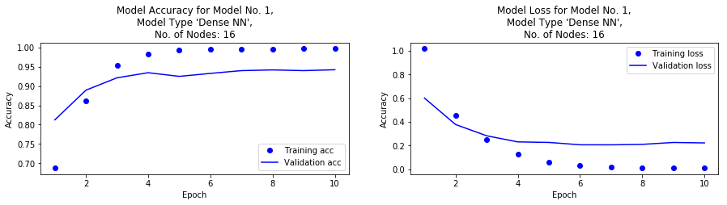

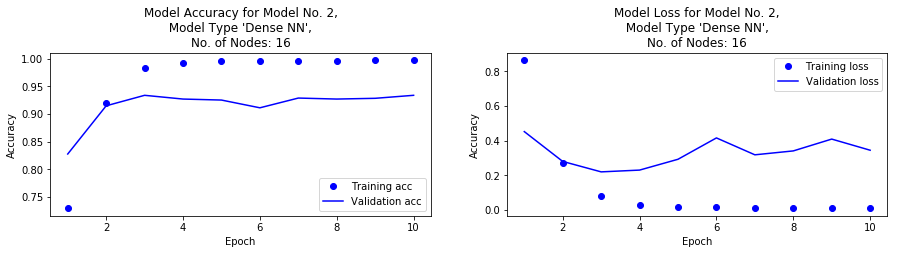

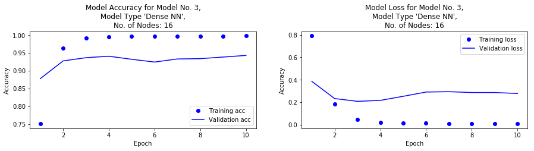

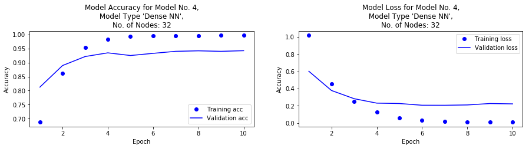

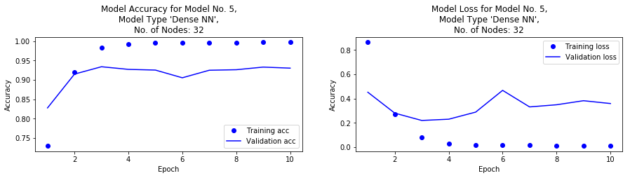

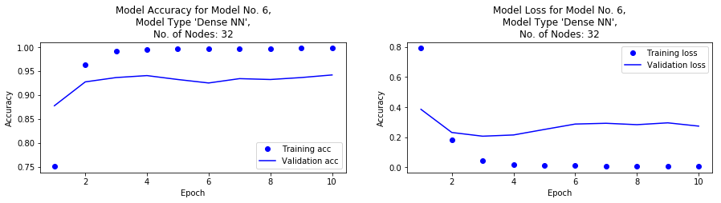

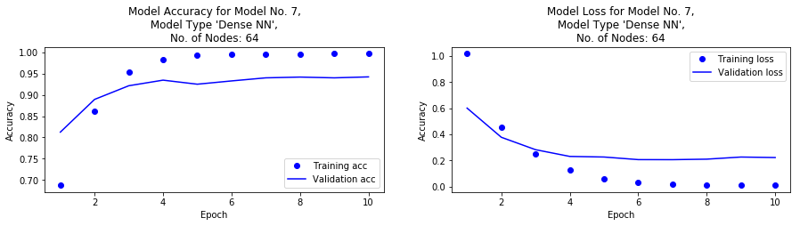

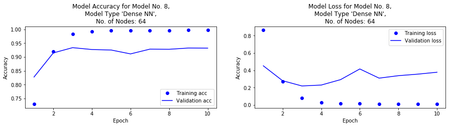

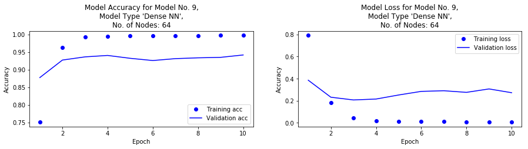

```python
# Create a loop to iterate through model variations
for nodes in mod_nodes:
    for hid_act in hidden_activation:

        # Print the basic parameters of the model being iterated
        print('---------------------------------------------------------------')
        print("Model No.: %r" %model_id)
        print("Model Type: %r" %model_type)
        print("Number of Layers: %r" %mod_layers)
        print("Number of Nodes: %r" %nodes)
        print("Hidden Layer Activiation: %r" %hid_act)
        print("Hidden Layer Optimizer: %r" %optimizer)

        start_time = time.clock() # start timer to evaluate how long it takes to train this base model

        # Set seeds for reproducible results
        seed(1)
        set_random_seed(2)
        rn.seed(3)

        # Define the model structure that is to be evaluated.
        model = Sequential()
        model.add(Embedding(max_words, embedding_dim, input_length=900))
        model.add(Flatten())
        model.add(Dense(32, activation=hid_act))
        model.add(Dense(9, activation=out_activation))
        #print(model.summary())

        model.compile(optimizer='rmsprop',
                      loss='categorical_crossentropy',
                      metrics=['acc'])

        history = model.fit(train_data, train_labels,
                            epochs=mod_epochs,
                            batch_size=mod_batch_size,
                            validation_data=(test_data, test_labels))

        #model.save_weights('pre_trained_glove_model.h5')

        # Stop the timer and append time to list
        end_time = time.clock() # end timer
        runtime = end_time - start_time  # seconds of wall-clock time
        print("\nProcessing time (seconds): %f" % runtime)  # print process time to train model
        processing_time.append(runtime) # append process time results to list for comparison table

        # Identify and print maximum accuracy and epoch where that accuracy was realized
        epoch_max = np.argmax(history.history['acc'])
        acc_max = max(history.history['acc'])
        print('Maxium Accuarcy: %r, Epochs Required to Achieve this Accuracy: %r' %(acc_max, epoch_max))

        # Print validation accuracy
        val_acc_max = max(history.history['val_acc'])
        print("Validation Accuracy: %r" %val_acc_max)

        # Plot the accuracy and loss of each model iteration
        plot_figs(model_id, model_type, nodes)

        # Append lists with values for this model ID
        model_id_list.append(model_id)
        model_type_list.append(model_type)
        embedding_dim_list.append(embedding_dim)
        article_len_list.append(article_len)
        n_layer_list.append(mod_layers)
        node_list.append(nodes)
        hidden_activation_list.append(hid_act)
        out_activation_list.append(out_activation)
        optimizer_list.append(optimizer)
        max_acc_list.append(acc_max)
        valid_perform_list.append(val_acc_max)
        epoch_max_list.append(epoch_max)
        batch_size_list.append(mod_batch_size)

        model_id += 1
```

```python
# round numbers in lists for readability
max_acc_list_formatted = [ '%.3f' % elem for elem in max_acc_list ]
valid_perform_list_formatted = [ '%.3f' % elem for elem in valid_perform_list]
```

```python
# Create a dictionary to store the results of the trained models from code above.
data = OrderedDict([('Model ID', model_id_list),
                    ('Model Type', model_type_list),
                    ('Embedding Dimensions', embedding_dim_list),
                    ('Article Word Length', article_len_list),
                    ('No. of Layers', n_layer_list),
                    ('Nodes', node_list),
                    ('Hidden Layer Activation', hidden_activation_list),
                    ('Output Layer Activation', out_activation_list),
                    ('Optimizer', optimizer_list),
                    ('Processing Time', processing_time),
                    ('Maximum Accuracy', max_acc_list_formatted),
                    ('Validation Accuracy', valid_perform_list_formatted),
                    ('No. of Epochs to Max Acc.',epoch_max_list),
                    ('Batch Size', batch_size_list)])
```

```python
# Pickle the data for use in the future without having to run models again.  Write to binary file
file_name = ('Exp_%s_Results.pickle' %exp_no)
with open(file_name, 'wb') as f:
    # Pickle the 'data' dictionary using the highest protocol available.
    pickle.dump(data, f, pickle.HIGHEST_PROTOCOL)

print('\n Run complete. Data objects sent to binary file %r' %file_name)
```

```
 Run complete. Data objects sent to binary file 'Exp_1_Results.pickle'
```

```python
# Extract objects from the dictionary object data
file_name = 'Exp_1_Results.pickle'
pickle_in = open(file_name,"rb")
data = pickle.load(pickle_in)

print('\n Loading of data complete. The binary file %r has been loaded' %file_name)
```

```
 Loading of data complete. The binary file 'Exp_1_Results.pickle' has been loaded
```

```python
# Create a table to display results of this experiment
results = pd.DataFrame(data)
print('\nTable 1: Benchmark Experiment: 1 Fully Connected Dense Neural Network Without Pretrained Embeddings\n')
results
```

```
Table 1: Benchmark Experiment: 1 Fully Connected Dense Neural Network Without Pretrained Embeddings
```

[output not shown]

#### Experiment #2 - Basic Dense Model With Pretrained Word Embeddings

```python
# Specify attributes about this model
exp_no = 2 # Experiment Number
model_type = 'Dense NN'
embedding_dim = 50
article_len = 900
mod_layers = 1
mod_nodes = [16, 32, 64]
hidden_activation = ['sigmoid','relu','tanh']
out_activation = 'softmax'
optimizer = 'rmsprop'
mod_epochs = 10
mod_batch_size = 32
```

```python
# Create lists to hold the results of each iteration.
model_id = 1 # initial model ID
model_id_list = []
model_type_list = []
embedding_dim_list = []
article_len_list = []
n_layer_list = []
node_list = []
hidden_activation_list = []
out_activation_list = []
optimizer_list = []
max_acc_list = []
valid_perform_list = []
epoch_max_list = []
batch_size_list = []
processing_time = []
```

```python
embedding_dim = 50

embedding_matrix = np.zeros((max_words, embedding_dim))
for word, i in word_index.items():
    if i < max_words:
        embedding_vector = embeddings_index_50d.get(word)
        if embedding_vector is not None:
            embedding_matrix[i] = embedding_vector
```

```
---------------------------------------------------------------
Model No.: 1
Model Type: 'Dense NN'
Number of Layers: 1
Number of Nodes: 16
Hidden Layer Activiation: 'sigmoid'
Hidden Layer Optimizer: 'rmsprop'
Train on 5583 samples, validate on 2208 samples

Processing time (seconds): 14.258427
Maxium Accuarcy: 0.5086870858708996, Epochs Required to Achieve this Accuracy: 3
Validation Accuracy: 0.4904891304347826
---------------------------------------------------------------
Model No.: 2
Model Type: 'Dense NN'
Number of Layers: 1
Number of Nodes: 16
Hidden Layer Activiation: 'relu'
Hidden Layer Optimizer: 'rmsprop'
Train on 5583 samples, validate on 2208 samples

Processing time (seconds): 13.860413
Maxium Accuarcy: 0.5086870858708996, Epochs Required to Achieve this Accuracy: 3
Validation Accuracy: 0.4904891304347826
---------------------------------------------------------------
Model No.: 3
Model Type: 'Dense NN'
Number of Layers: 1
Number of Nodes: 16
Hidden Layer Activiation: 'tanh'
Hidden Layer Optimizer: 'rmsprop'
Train on 5583 samples, validate on 2208 samples

Processing time (seconds): 13.844733
Maxium Accuarcy: 0.5086870858708996, Epochs Required to Achieve this Accuracy: 3
Validation Accuracy: 0.4904891304347826
---------------------------------------------------------------
Model No.: 4
Model Type: 'Dense NN'
Number of Layers: 1
```

[output cut: 53 more lines]

```
Processing time (seconds): 14.223301
Maxium Accuarcy: 0.5086870858708996, Epochs Required to Achieve this Accuracy: 3
Validation Accuracy: 0.4904891304347826
---------------------------------------------------------------
Model No.: 9
Model Type: 'Dense NN'
Number of Layers: 1
Number of Nodes: 64
Hidden Layer Activiation: 'tanh'
Hidden Layer Optimizer: 'rmsprop'
Train on 5583 samples, validate on 2208 samples

Processing time (seconds): 14.612579
Maxium Accuarcy: 0.5086870858708996, Epochs Required to Achieve this Accuracy: 3
Validation Accuracy: 0.4904891304347826
```

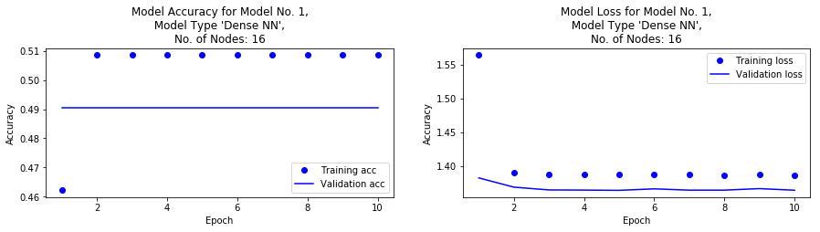

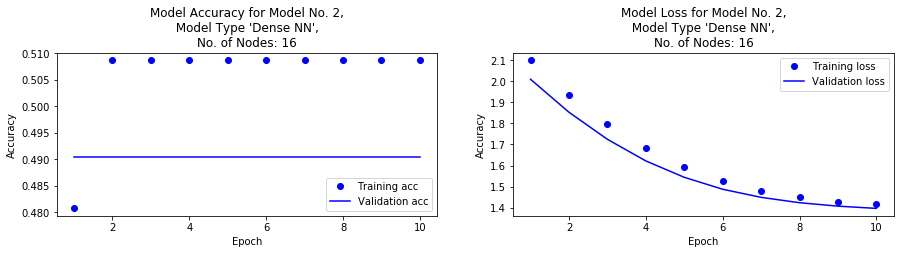

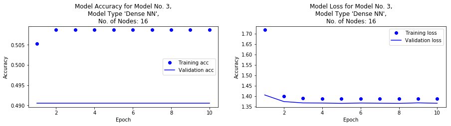

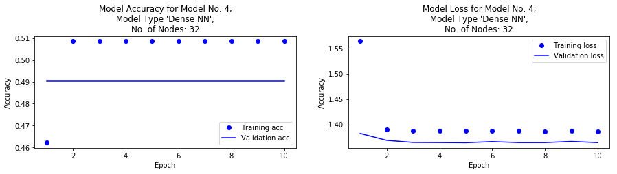

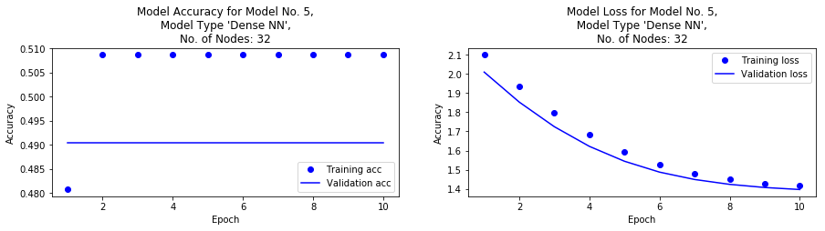

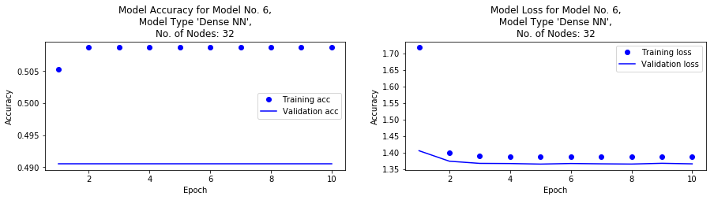

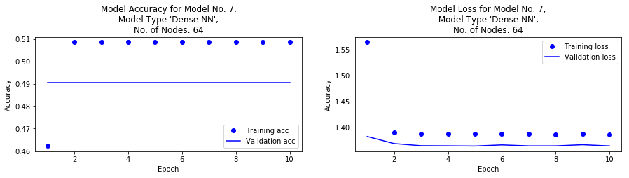

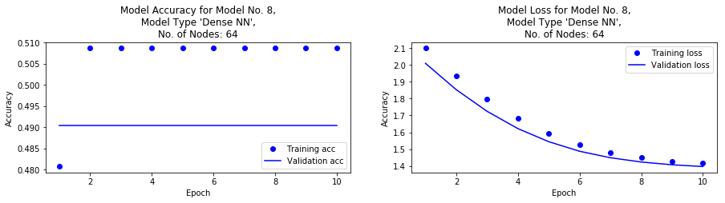

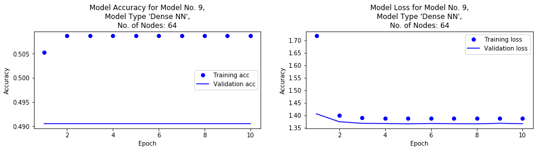

```python
# Create a loop to iterate through model variations
for nodes in mod_nodes:
    for hid_act in hidden_activation:

        # Print the basic parameters of the model being iterated
        print('---------------------------------------------------------------')
        print("Model No.: %r" %model_id)
        print("Model Type: %r" %model_type)
        print("Number of Layers: %r" %mod_layers)
        print("Number of Nodes: %r" %nodes)
        print("Hidden Layer Activiation: %r" %hid_act)
        print("Hidden Layer Optimizer: %r" %optimizer)

        start_time = time.clock() # start timer to evaluate how long it takes to train this base model

        # Set seeds for reproducible results
        seed(1)
        set_random_seed(2)
        rn.seed(3)

        # Define the model structure that is to be evaluated.
        model = Sequential()
        model.add(Embedding(max_words, embedding_dim, input_length=900))
        model.add(Flatten())
        model.add(Dense(32, activation=hid_act))
        model.add(Dense(9, activation=out_activation))
        #print(model.summary())

        model.layers[0].set_weights([embedding_matrix])
        model.layers[0].trainable = False

        model.compile(optimizer='rmsprop',
                      loss='categorical_crossentropy',
                      metrics=['acc'])

        history = model.fit(train_data, train_labels,
                            epochs=mod_epochs,
                            batch_size=mod_batch_size,
                            validation_data=(test_data, test_labels))

        #model.save_weights('pre_trained_glove_model.h5')

        # Stop the timer and append time to list
        end_time = time.clock() # end timer
        runtime = end_time - start_time  # seconds of wall-clock time
        print("\nProcessing time (seconds): %f" % runtime)  # print process time to train model
        processing_time.append(runtime) # append process time results to list for comparison table

        # Identify and print maximum accuracy and epoch where that accuracy was realized
        epoch_max = np.argmax(history.history['acc'])
        acc_max = max(history.history['acc'])
        print('Maxium Accuarcy: %r, Epochs Required to Achieve this Accuracy: %r' %(acc_max, epoch_max))

        # Print validation accuracy
        val_acc_max = max(history.history['val_acc'])
        print("Validation Accuracy: %r" %val_acc_max)

        # Plot the accuracy and loss of each model iteration
        plot_figs(model_id, model_type, nodes)

        # Append lists with values for this model ID
        model_id_list.append(model_id)
        model_type_list.append(model_type)
        embedding_dim_list.append(embedding_dim)
        article_len_list.append(article_len)
        n_layer_list.append(mod_layers)
        node_list.append(nodes)
        hidden_activation_list.append(hid_act)
        out_activation_list.append(out_activation)
        optimizer_list.append(optimizer)
        max_acc_list.append(acc_max)
        valid_perform_list.append(val_acc_max)
        epoch_max_list.append(epoch_max)
        batch_size_list.append(mod_batch_size)

        model_id += 1
```

```python
# round numbers in lists for readability
max_acc_list_formatted = [ '%.3f' % elem for elem in max_acc_list ]
valid_perform_list_formatted = [ '%.3f' % elem for elem in valid_perform_list]
```

```python
# Create a dictionary to store the results of the trained models from code above.
data = OrderedDict([('Model ID', model_id_list),
                    ('Model Type', model_type_list),
                    ('Embedding Dimensions', embedding_dim_list),
                    ('Article Word Length', article_len_list),
                    ('No. of Layers', n_layer_list),
                    ('Nodes', node_list),
                    ('Hidden Layer Activation', hidden_activation_list),
                    ('Output Layer Activation', out_activation_list),
                    ('Optimizer', optimizer_list),
                    ('Processing Time', processing_time),
                    ('Maximum Accuracy', max_acc_list_formatted),
                    ('Validation Accuracy', valid_perform_list_formatted),
                    ('No. of Epochs to Max Acc.',epoch_max_list),
                    ('Batch Size', batch_size_list)])
```

```python
# Pickle the data for use in the future without having to run models again.  Write to binary file
file_name = ('Exp_%s_Results.pickle' %exp_no)
with open(file_name, 'wb') as f:
    # Pickle the 'data' dictionary using the highest protocol available.
    pickle.dump(data, f, pickle.HIGHEST_PROTOCOL)

print('\n Run complete. Data objects sent to binary file %r' %file_name)
```

```
 Run complete. Data objects sent to binary file 'Exp_2_Results.pickle'
```

```python
# Extract objects from the dictionary object data
file_name = 'Exp_2_Results.pickle'
pickle_in = open(file_name,"rb")
data = pickle.load(pickle_in)

print('\n Loading of data complete. The binary file %r has been loaded' %file_name)
```

```
 Loading of data complete. The binary file 'Exp_2_Results.pickle' has been loaded
```

```python
# Create a table to display results of this experiment
results = pd.DataFrame(data)
print('\nTable 2: Benchmark Experiment: 1 Fully Connected Dense Neural Network With Pretrained Embeddings\n')
results
```

```
Table 2: Benchmark Experiment: 1 Fully Connected Dense Neural Network With Pretrained Embeddings
```

|  | Model ID | Model Type | Embedding Dimensions | Article Word Length | No. of Layers | Nodes | Hidden Layer Activation | Output Layer Activation | Optimizer | Processing Time | Max Train Accuracy | Max Validation Accuracy | No. of Epochs to Max Acc. | Batch Size |
| --- | --- | --- | --- | --- | --- | --- | --- | --- | --- | --- | --- | --- | --- | --- |
| 0 | 1 | Dense NN | 50 | 900 | 1 | 16 | sigmoid | softmax | rmsprop | 16.903115 | 0.509 | 0.490 | 3 | 32 |
| 1 | 2 | Dense NN | 50 | 900 | 1 | 16 | relu | softmax | rmsprop | 16.902132 | 0.509 | 0.490 | 3 | 32 |
| 2 | 3 | Dense NN | 50 | 900 | 1 | 16 | tanh | softmax | rmsprop | 16.807636 | 0.509 | 0.490 | 3 | 32 |
| 3 | 4 | Dense NN | 50 | 900 | 1 | 32 | sigmoid | softmax | rmsprop | 16.573466 | 0.509 | 0.490 | 3 | 32 |
| 4 | 5 | Dense NN | 50 | 900 | 1 | 32 | relu | softmax | rmsprop | 16.203134 | 0.509 | 0.490 | 3 | 32 |
| 5 | 6 | Dense NN | 50 | 900 | 1 | 32 | tanh | softmax | rmsprop | 16.670262 | 0.509 | 0.490 | 3 | 32 |
| 6 | 7 | Dense NN | 50 | 900 | 1 | 64 | sigmoid | softmax | rmsprop | 17.363022 | 0.509 | 0.490 | 3 | 32 |
| 7 | 8 | Dense NN | 50 | 900 | 1 | 64 | relu | softmax | rmsprop | 16.668478 | 0.509 | 0.490 | 3 | 32 |
| 8 | 9 | Dense NN | 50 | 900 | 1 | 64 | tanh | softmax | rmsprop | 16.832492 | 0.509 | 0.490 | 3 | 32 |

#### Experiment #3 - Explore a Simple RNN

```python
# Specify attributes about this model
exp_no = 3 # Experiment Number
model_type = 'RNN'
embedding_dim = 50
article_len = 900
mod_layers = 1
mod_nodes = [16, 32, 64]
out_activation = 'softmax'
optimizer = ['sgd','adam','adagrad','rmsprop']
mod_epochs = 10
mod_batch_size = 32
```

```python
# Create lists to hold the results of each iteration.
model_id = 1 # initial model ID
model_id_list = []
model_type_list = []
embedding_dim_list = []
article_len_list = []
n_layer_list = []
node_list = []
out_activation_list = []
optimizer_list = []
max_acc_list = []
valid_perform_list = []
epoch_max_list = []
batch_size_list = []
processing_time = []
```

```
---------------------------------------------------------------
Model No.: 1
Model Type: 'RNN'
Number of Layers: 1
Number of Nodes: 16
Hidden Layer Optimizer: 'sgd'
Train on 5583 samples, validate on 2208 samples

Processing time (seconds): 496.353599
Maxium Accuarcy: 0.5855274942534896, Epochs Required to Achieve this Accuracy: 7
Validation Accuracy: 0.6911231884057971
---------------------------------------------------------------
Model No.: 2
Model Type: 'RNN'
Number of Layers: 1
Number of Nodes: 16
Hidden Layer Optimizer: 'adam'
Train on 5583 samples, validate on 2208 samples

Processing time (seconds): 494.747865
Maxium Accuarcy: 0.9903277807630306, Epochs Required to Achieve this Accuracy: 9
Validation Accuracy: 0.6951992753623188
---------------------------------------------------------------
Model No.: 3
Model Type: 'RNN'
Number of Layers: 1
Number of Nodes: 16
Hidden Layer Optimizer: 'adagrad'
Train on 5583 samples, validate on 2208 samples

Processing time (seconds): 495.129817
Maxium Accuarcy: 0.7023105857279616, Epochs Required to Achieve this Accuracy: 9
Validation Accuracy: 0.5778985507246377
---------------------------------------------------------------
Model No.: 4
Model Type: 'RNN'
Number of Layers: 1
Number of Nodes: 16
Hidden Layer Optimizer: 'rmsprop'
Train on 5583 samples, validate on 2208 samples
```

[output cut: 77 more lines]

```

Processing time (seconds): 499.142708
Maxium Accuarcy: 0.8733655740641232, Epochs Required to Achieve this Accuracy: 9
Validation Accuracy: 0.7228260869565217
---------------------------------------------------------------
Model No.: 12
Model Type: 'RNN'
Number of Layers: 1
Number of Nodes: 64
Hidden Layer Optimizer: 'rmsprop'
Train on 5583 samples, validate on 2208 samples

Processing time (seconds): 500.870915
Maxium Accuarcy: 0.9957012358946803, Epochs Required to Achieve this Accuracy: 9
Validation Accuracy: 0.8378623188405797
```

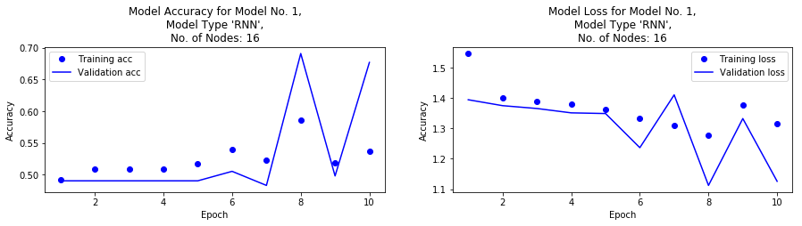

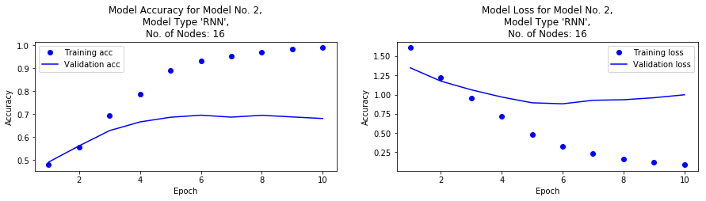

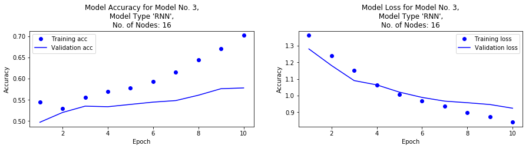

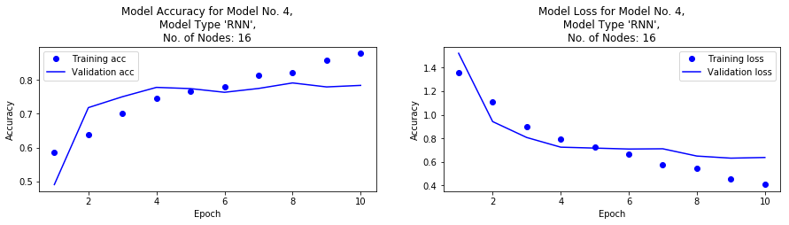

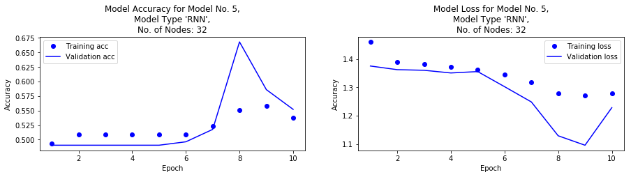

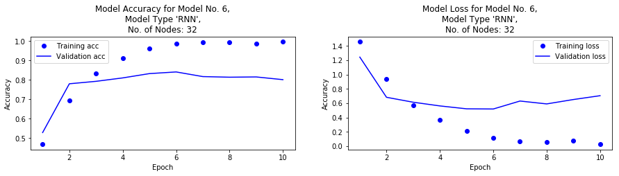

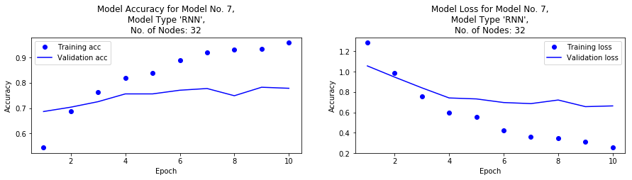

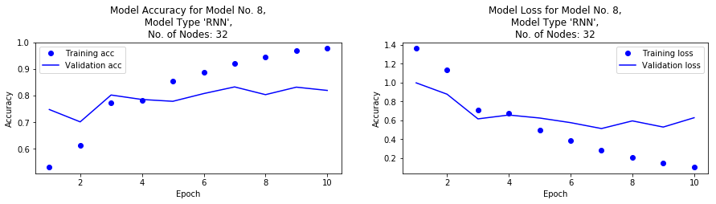

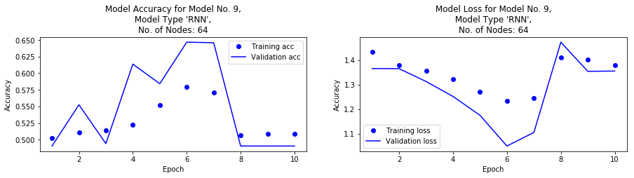

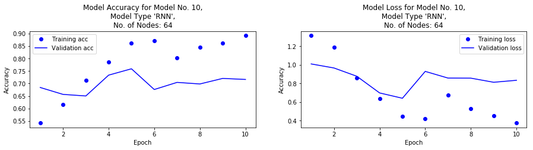

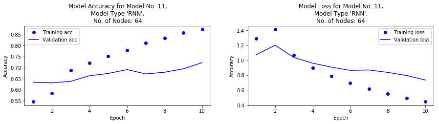

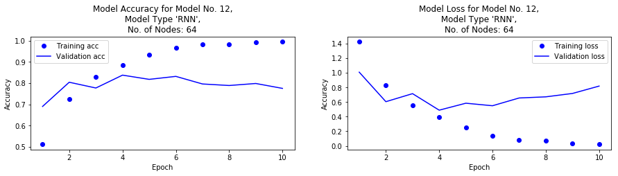

```python
# Create a loop to iterate through model variations
for nodes in mod_nodes:
    for opt in optimizer:


        # Print the basic parameters of the model being iterated
        print('---------------------------------------------------------------')
        print("Model No.: %r" %model_id)
        print("Model Type: %r" %model_type)
        print("Number of Layers: %r" %mod_layers)
        print("Number of Nodes: %r" %nodes)
        print("Hidden Layer Optimizer: %r" %opt)

        start_time = time.clock() # start timer to evaluate how long it takes to train this base model

        # Set seeds for reproducible results
        seed(1)
        set_random_seed(2)
        rn.seed(3)

        # Define the model structure that is to be evaluated.
        model = Sequential()
        model.add(Embedding(input_dim=max_words,
                            output_dim=nodes))
        model.add(SimpleRNN(nodes))
        model.add(Dense(9, activation=out_activation))
        #print(model.summary())

        model.compile(optimizer=opt,
                      loss='categorical_crossentropy',
                      metrics=['acc'])

        history = model.fit(train_data, train_labels,
                            epochs=mod_epochs,
                            batch_size=mod_batch_size,
                            validation_data=(test_data, test_labels))

        #model.save_weights('pre_trained_glove_model.h5')

        # Stop the timer and append time to list
        end_time = time.clock() # end timer
        runtime = end_time - start_time  # seconds of wall-clock time
        print("\nProcessing time (seconds): %f" % runtime)  # print process time to train model
        processing_time.append(runtime) # append process time results to list for comparison table

        # Identify and print maximum accuracy and epoch where that accuracy was realized
        epoch_max = np.argmax(history.history['acc'])
        acc_max = max(history.history['acc'])
        print('Maxium Accuarcy: %r, Epochs Required to Achieve this Accuracy: %r' %(acc_max, epoch_max))

        # Print validation accuracy
        val_acc_max = max(history.history['val_acc'])
        print("Validation Accuracy: %r" %val_acc_max)

        # Plot the accuracy and loss of each model iteration
        plot_figs(model_id, model_type, nodes)

        # Append lists with values for this model ID
        model_id_list.append(model_id)
        model_type_list.append(model_type)
        embedding_dim_list.append(embedding_dim)
        article_len_list.append(article_len)
        n_layer_list.append(mod_layers)
        node_list.append(nodes)
        out_activation_list.append(out_activation)
        optimizer_list.append(opt)
        max_acc_list.append(acc_max)
        valid_perform_list.append(val_acc_max)
        epoch_max_list.append(epoch_max)
        batch_size_list.append(mod_batch_size)

        model_id += 1
```

```python
# round numbers in lists for readability
max_acc_list_formatted = [ '%.3f' % elem for elem in max_acc_list ]
valid_perform_list_formatted = [ '%.3f' % elem for elem in valid_perform_list]
```

```python
# Create a dictionary to store the results of the trained models from code above.
data = OrderedDict([('Model ID', model_id_list),
                    ('Model Type', model_type_list),
                    ('Embedding Dimensions', embedding_dim_list),
                    ('Article Word Length', article_len_list),
                    ('No. of Layers', n_layer_list),
                    ('Nodes', node_list),
                    ('Output Layer Activation', out_activation_list),
                    ('Optimizer', optimizer_list),
                    ('Processing Time', processing_time),
                    ('Maximum Accuracy', max_acc_list_formatted),
                    ('Validation Accuracy', valid_perform_list_formatted),
                    ('No. of Epochs to Max Acc.',epoch_max_list),
                    ('Batch Size', batch_size_list)])
```

```python
# Pickle the data for use in the future without having to run models again.  Write to binary file
file_name = ('Exp_%s_Results.pickle' %exp_no)
with open(file_name, 'wb') as f:
    # Pickle the 'data' dictionary using the highest protocol available.
    pickle.dump(data, f, pickle.HIGHEST_PROTOCOL)

print('\n Run complete. Data objects sent to binary file %r' %file_name)
```

```
 Run complete. Data objects sent to binary file 'Exp_3_Results.pickle'
```

```python
# Extract objects from the dictionary object data
file_name = 'Exp_3_Results.pickle'
pickle_in = open(file_name,"rb")
data = pickle.load(pickle_in)

print('\n Loading of data complete. The binary file %r has been loaded' %file_name)
```

```
 Loading of data complete. The binary file 'Exp_3_Results.pickle' has been loaded
```

```python
# Create a table to display results of this experiment
results = pd.DataFrame(data)
print('\nTable 3: Benchmark Experiment: Simple 1-layer RNN Model Without Pretrained Embeddings\n')
results
```

```
Table 3: Benchmark Experiment: Simple 1-layer RNN Model Without Pretrained Embeddings
```

|  | Model ID | Model Type | Embedding Dimensions | Article Word Length | No. of Layers | Nodes | Output Layer Activation | Optimizer | Processing Time | Max Train Accuracy | Max Validation Accuracy | No. of Epochs to Max Acc. | Batch Size |
| --- | --- | --- | --- | --- | --- | --- | --- | --- | --- | --- | --- | --- | --- |
| 0 | 1 | RNN | 50 | 900 | 1 | 16 | softmax | sgd | 496.353599 | 0.586 | 0.691 | 7 | 32 |
| 1 | 2 | RNN | 50 | 900 | 1 | 16 | softmax | adam | 494.747865 | 0.990 | 0.695 | 9 | 32 |
| 2 | 3 | RNN | 50 | 900 | 1 | 16 | softmax | adagrad | 495.129817 | 0.702 | 0.578 | 9 | 32 |
| 3 | 4 | RNN | 50 | 900 | 1 | 16 | softmax | rmsprop | 494.798767 | 0.878 | 0.791 | 9 | 32 |
| 4 | 5 | RNN | 50 | 900 | 1 | 32 | softmax | sgd | 496.292395 | 0.558 | 0.668 | 8 | 32 |
| 5 | 6 | RNN | 50 | 900 | 1 | 32 | softmax | adam | 500.118694 | 0.997 | 0.841 | 9 | 32 |
| 6 | 7 | RNN | 50 | 900 | 1 | 32 | softmax | adagrad | 496.111601 | 0.959 | 0.783 | 9 | 32 |
| 7 | 8 | RNN | 50 | 900 | 1 | 32 | softmax | rmsprop | 506.072677 | 0.977 | 0.832 | 9 | 32 |
| 8 | 9 | RNN | 50 | 900 | 1 | 64 | softmax | sgd | 500.660398 | 0.579 | 0.647 | 5 | 32 |
| 9 | 10 | RNN | 50 | 900 | 1 | 64 | softmax | adam | 501.459791 | 0.892 | 0.759 | 9 | 32 |
| 10 | 11 | RNN | 50 | 900 | 1 | 64 | softmax | adagrad | 499.142708 | 0.873 | 0.723 | 9 | 32 |
| 11 | 12 | RNN | 50 | 900 | 1 | 64 | softmax | rmsprop | 500.870915 | 0.996 | 0.838 | 9 | 32 |

#### Experiment #4 - Compare Basic RNN to LSTM and GRU

```python
# Specify attributes about this model
exp_no = 4 # Experiment Number
model_type = 'RNN'
embedding_dim = 50
article_len = 900
mod_layers = 1
layer_type = 'LSTM'
mod_nodes = 64
out_activation = 'softmax'
optimizer = 'rmsprop'
mod_epochs = 10
mod_batch_size = 32
```

```python
# Create lists to hold the results of each iteration.
model_id = 1 # initial model ID
model_id_list = []
model_type_list = []
embedding_dim_list = []
article_len_list = []
n_layer_list = []
layer_type_list = []
node_list = []
out_activation_list = []
optimizer_list = []
max_acc_list = []
valid_perform_list = []
epoch_max_list = []
batch_size_list = []
processing_time = []
```

```
---------------------------------------------------------------
Model No.: 1
Model Type: 'RNN'
Number of Layers: 1
Layer Type: 'LSTM'
Number of Nodes: 64
Hidden Layer Optimizer: 'rmsprop'
Train on 5583 samples, validate on 2208 samples

Processing time (seconds): 2226.513371
Maxium Accuarcy: 0.969729536091707, Epochs Required to Achieve this Accuracy: 9
Validation Accuracy: 0.9347826086956522
```

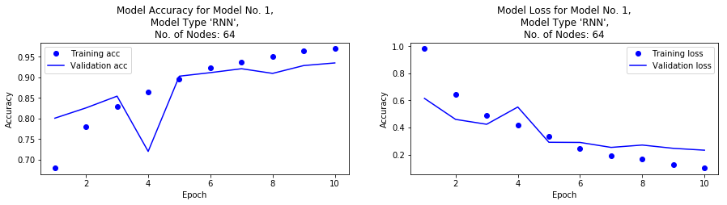

```python
# Print the basic parameters of the model being iterated
print('---------------------------------------------------------------')
print("Model No.: %r" %model_id)
print("Model Type: %r" %model_type)
print("Number of Layers: %r" %mod_layers)
print("Layer Type: %r" %layer_type)
print("Number of Nodes: %r" %mod_nodes)
print("Hidden Layer Optimizer: %r" %optimizer)

start_time = time.clock() # start timer to evaluate how long it takes to train this base model

# Set seeds for reproducible results
seed(1)
set_random_seed(2)
rn.seed(3)

# Define the model structure that is to be evaluated.
model = Sequential()
model.add(Embedding(input_dim=max_words,
                    output_dim=mod_nodes))
model.add(LSTM(mod_nodes))
model.add(Dense(9, activation=out_activation))
#print(model.summary())

model.compile(optimizer=optimizer,
              loss='categorical_crossentropy',
              metrics=['acc'])

history = model.fit(train_data, train_labels,
                    epochs=mod_epochs,
                    batch_size=mod_batch_size,
                    validation_data=(test_data, test_labels))

#model.save_weights('pre_trained_glove_model.h5')

# Stop the timer and append time to list
end_time = time.clock() # end timer
runtime = end_time - start_time  # seconds of wall-clock time
print("\nProcessing time (seconds): %f" % runtime)  # print process time to train model
processing_time.append(runtime) # append process time results to list for comparison table

# Identify and print maximum accuracy and epoch where that accuracy was realized
epoch_max = np.argmax(history.history['acc'])
acc_max = max(history.history['acc'])
print('Maxium Accuarcy: %r, Epochs Required to Achieve this Accuracy: %r' %(acc_max, epoch_max))

# Print validation accuracy
val_acc_max = max(history.history['val_acc'])
print("Validation Accuracy: %r" %val_acc_max)

# Plot the accuracy and loss of each model iteration
plot_figs(model_id, model_type, mod_nodes)

# Append lists with values for this model ID
model_id_list.append(model_id)
model_type_list.append(model_type)
embedding_dim_list.append(embedding_dim)
article_len_list.append(article_len)
n_layer_list.append(mod_layers)
layer_type_list.append(layer_type)
node_list.append(mod_nodes)
out_activation_list.append(out_activation)
optimizer_list.append(optimizer)
max_acc_list.append(acc_max)
valid_perform_list.append(val_acc_max)
epoch_max_list.append(epoch_max)
batch_size_list.append(mod_batch_size)

model_id += 1
```

```python
# Specify attributes about this model
exp_no = 4 # Experiment Number
model_type = 'RNN'
embedding_dim = 50
article_len = 900
mod_layers = 1
layer_type = 'GRU'
mod_nodes = 64
out_activation = 'softmax'
optimizer = 'rmsprop'
mod_epochs = 10
mod_batch_size = 32
```

```
---------------------------------------------------------------
Model No.: 2
Model Type: 'RNN'
Number of Layers: 1
Layer Type: 'GRU'
Number of Nodes: 64
Hidden Layer Optimizer: 'rmsprop'
Train on 5583 samples, validate on 2208 samples

Processing time (seconds): 1711.124659
Maxium Accuarcy: 0.9674010388786682, Epochs Required to Achieve this Accuracy: 9
Validation Accuracy: 0.9243659420289855
```

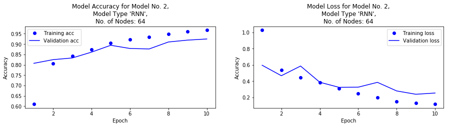

```python
# Print the basic parameters of the model being iterated
print('---------------------------------------------------------------')
print("Model No.: %r" %model_id)
print("Model Type: %r" %model_type)
print("Number of Layers: %r" %mod_layers)
print("Layer Type: %r" %layer_type)
print("Number of Nodes: %r" %mod_nodes)
print("Hidden Layer Optimizer: %r" %optimizer)

start_time = time.clock() # start timer to evaluate how long it takes to train this base model

# Set seeds for reproducible results
seed(1)
set_random_seed(2)
rn.seed(3)

# Define the model structure that is to be evaluated.
model = Sequential()
model.add(Embedding(input_dim=max_words,
                    output_dim=mod_nodes))
model.add(GRU(mod_nodes))
model.add(Dense(9, activation=out_activation))
#print(model.summary())

model.compile(optimizer=optimizer,
              loss='categorical_crossentropy',
              metrics=['acc'])

history = model.fit(train_data, train_labels,
                    epochs=mod_epochs,
                    batch_size=mod_batch_size,
                    validation_data=(test_data, test_labels))

#model.save_weights('pre_trained_glove_model.h5')

# Stop the timer and append time to list
end_time = time.clock() # end timer
runtime = end_time - start_time  # seconds of wall-clock time
print("\nProcessing time (seconds): %f" % runtime)  # print process time to train model
processing_time.append(runtime) # append process time results to list for comparison table

# Identify and print maximum accuracy and epoch where that accuracy was realized
epoch_max = np.argmax(history.history['acc'])
acc_max = max(history.history['acc'])
print('Maxium Accuarcy: %r, Epochs Required to Achieve this Accuracy: %r' %(acc_max, epoch_max))

# Print validation accuracy
val_acc_max = max(history.history['val_acc'])
print("Validation Accuracy: %r" %val_acc_max)

# Plot the accuracy and loss of each model iteration
plot_figs(model_id, model_type, mod_nodes)

# Append lists with values for this model ID
model_id_list.append(model_id)
model_type_list.append(model_type)
embedding_dim_list.append(embedding_dim)
article_len_list.append(article_len)
n_layer_list.append(mod_layers)
layer_type_list.append(layer_type)
node_list.append(mod_nodes)
out_activation_list.append(out_activation)
optimizer_list.append(optimizer)
max_acc_list.append(acc_max)
valid_perform_list.append(val_acc_max)
epoch_max_list.append(epoch_max)
batch_size_list.append(mod_batch_size)

model_id += 1
```

```python
# round numbers in lists for readability
max_acc_list_formatted = [ '%.3f' % elem for elem in max_acc_list ]
valid_perform_list_formatted = [ '%.3f' % elem for elem in valid_perform_list]
```

```python
# Create a dictionary to store the results of the trained models from code above.
data = OrderedDict([('Model ID', model_id_list),
                    ('Model Type', model_type_list),
                    ('Embedding Dimensions', embedding_dim_list),
                    ('Article Word Length', article_len_list),
                    ('No. of Layers', n_layer_list),
                    ('Layer Type', layer_type_list),
                    ('Nodes', node_list),
                    ('Output Layer Activation', out_activation_list),
                    ('Optimizer', optimizer_list),
                    ('Processing Time', processing_time),
                    ('Maximum Accuracy', max_acc_list_formatted),
                    ('Validation Accuracy', valid_perform_list_formatted),
                    ('No. of Epochs to Max Acc.',epoch_max_list),
                    ('Batch Size', batch_size_list)])
```

```python
# Pickle the data for use in the future without having to run models again.  Write to binary file
file_name = ('Exp_%s_GRU_Results.pickle' %exp_no)
with open(file_name, 'wb') as f:
    # Pickle the 'data' dictionary using the highest protocol available.
    pickle.dump(data, f, pickle.HIGHEST_PROTOCOL)

print('\n Run complete. Data objects sent to binary file %r' %file_name)
```

```
 Run complete. Data objects sent to binary file 'Exp_4_GRU_Results.pickle'
```

```python
# Extract objects from the dictionary object data
file_name = 'Exp_4_Results.pickle'
pickle_in = open(file_name,"rb")
data = pickle.load(pickle_in)

print('\n Loading of data complete. The binary file %r has been loaded' %file_name)
```

```
 Loading of data complete. The binary file 'Exp_4_Results.pickle' has been loaded
```

```python
# Create a table to display results of this experiment
results = pd.DataFrame(data)
print('\nTable 4: Benchmark Experiment: 1-Layer RNN Comparison of LSTM and GRU Model Without Pretrained Embeddings\n')
results
```

```
Table 4: Benchmark Experiment: 1-Layer RNN Comparison of LSTM and GRU Model Without Pretrained Embeddings
```

|  | Model ID | Model Type | Embedding Dimensions | Article Word Length | No. of Layers | Layer Type | Nodes | Output Layer Activation | Optimizer | Processing Time | Max Train Accuracy | Max Validation Accuracy | No. of Epochs to Max Acc. | Batch Size |
| --- | --- | --- | --- | --- | --- | --- | --- | --- | --- | --- | --- | --- | --- | --- |
| 0 | 1 | RNN | 50 | 900 | 1 | LSTM | 64 | softmax | rmsprop | 2185.902832 | 0.974 | 0.928 | 9 | 32 |
| 1 | 2 | RNN | 50 | 900 | 1 | GRU | 64 | softmax | rmsprop | 1676.757512 | 0.968 | 0.922 | 9 | 32 |